# IODS course project

## Week 5: Dimensionality reduction techinques

This week’s exercises were about multiple dimensions and how to deal with them. **Dimanesionality reduction techinques** help to decrease the dimensions of phenomena so that they are easier to understand and visualize. It is not rare to have dozens of dimensions so it can be really useful to narrow them down. But this must be done so that we don’t lose any important information about the variables - only the irrelevant dimensions that cause noise! We are using two different methods in this report: *principal component analysis (PCA)* and *multiple correspondence analysis (MCA)*.

### The data

The data we are using is from [United Nations Development Programme](http://hdr.undp.org/en/content/human-development-index-hdi) and the datasets are about Human Development Index and Gender Inequality Index. In previous week’s data wrangling exercise those two separate datasets were merged and some of the variables were little bit changed. So we are using one dataset called `human` that looks like this:

```r
human <- read.csv("~/IODS-project/data/human2.csv", row.names = 1)
str(human)
```

```
## 'data.frame':    155 obs. of  8 variables:
##  $ edu_ratio: num  0.198 0.931 0.861 0.977 0.989 ...
##  $ lab_ratio: num  0.199 0.685 0.211 0.633 0.747 ...
##  $ edu_exp  : num  9.3 11.8 14 17.9 12.3 20.2 15.7 11.9 12.6 14.4 ...
##  $ life_exp : num  60.4 77.8 74.8 76.3 74.7 82.4 81.4 70.8 75.4 76.6 ...
##  $ gni      : int  1885 9943 13054 22050 8124 42261 43869 16428 21336 38599 ...
##  $ mmr      : int  400 21 89 69 29 6 4 26 37 22 ...
##  $ birth    : num  86.8 15.3 10 54.4 27.1 12.1 4.1 40 28.5 13.8 ...
##  $ parl     : num  27.6 20.7 25.7 36.8 10.7 30.5 30.3 15.6 16.7 15 ...
```

```r
summary(human)
```

```
##    edu_ratio        lab_ratio         edu_exp         life_exp
##  Min.   :0.1717   Min.   :0.1857   Min.   : 5.40   Min.   :49.00
##  1st Qu.:0.7264   1st Qu.:0.5984   1st Qu.:11.25   1st Qu.:66.30
##  Median :0.9375   Median :0.7535   Median :13.50   Median :74.20
##  Mean   :0.8529   Mean   :0.7074   Mean   :13.18   Mean   :71.65
##  3rd Qu.:0.9968   3rd Qu.:0.8535   3rd Qu.:15.20   3rd Qu.:77.25
##  Max.   :1.4967   Max.   :1.0380   Max.   :20.20   Max.   :83.50
##       gni              mmr             birth             parl
##  Min.   :   581   Min.   :   1.0   Min.   :  0.60   Min.   : 0.00
##  1st Qu.:  4198   1st Qu.:  11.5   1st Qu.: 12.65   1st Qu.:12.40
##  Median : 12040   Median :  49.0   Median : 33.60   Median :19.30
##  Mean   : 17628   Mean   : 149.1   Mean   : 47.16   Mean   :20.91
##  3rd Qu.: 24512   3rd Qu.: 190.0   3rd Qu.: 71.95   3rd Qu.:27.95
##  Max.   :123124   Max.   :1100.0   Max.   :204.80   Max.   :57.50
```

This data has 8 variables and 155 observations. Observations are named by countrys that rows are representing so the country name is not a seperate variable. We can see that there are no variables that have string as datatype. Ranges of variables differ a lot from each other. It seems pretty logical since for example `gni` that stands for Gross National Income measures money amounts and for example `edu_ratio` measures the secondary education rate between males and females.

Next we would like to know how the variables distribute and correlate with each other. It would give to us a little bit perspective about the relationships in the dataset. Here are histograms of the variables and a correlation matrix that will show all correlations between the variables:

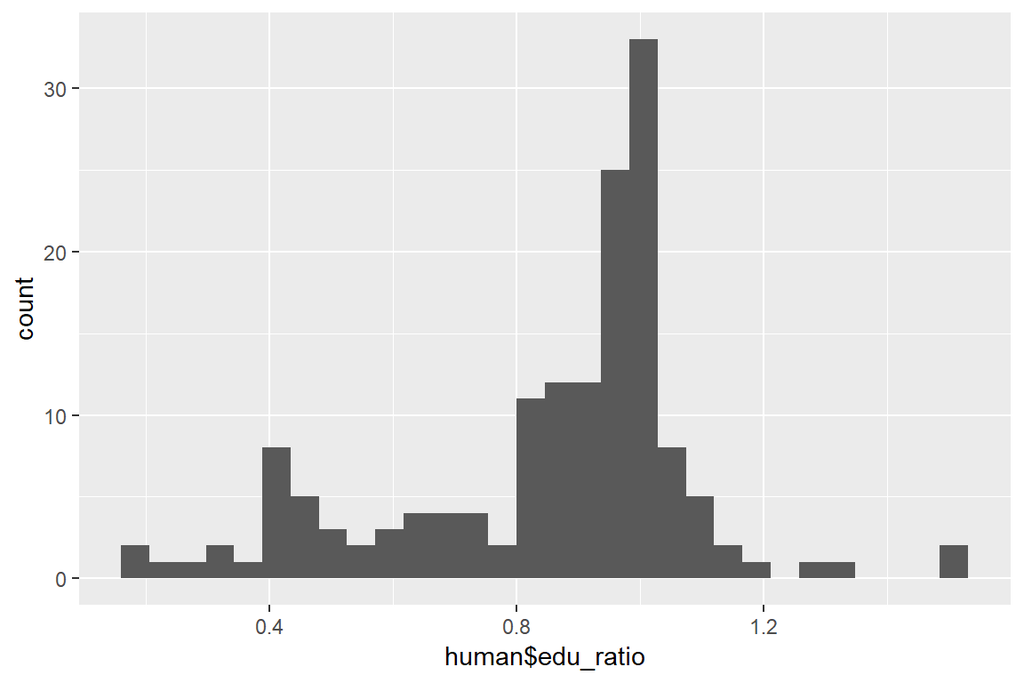

```r
library(ggplot2)
library(corrplot)

ggplot(data = human, aes(human$edu_ratio)) + geom_histogram()
```

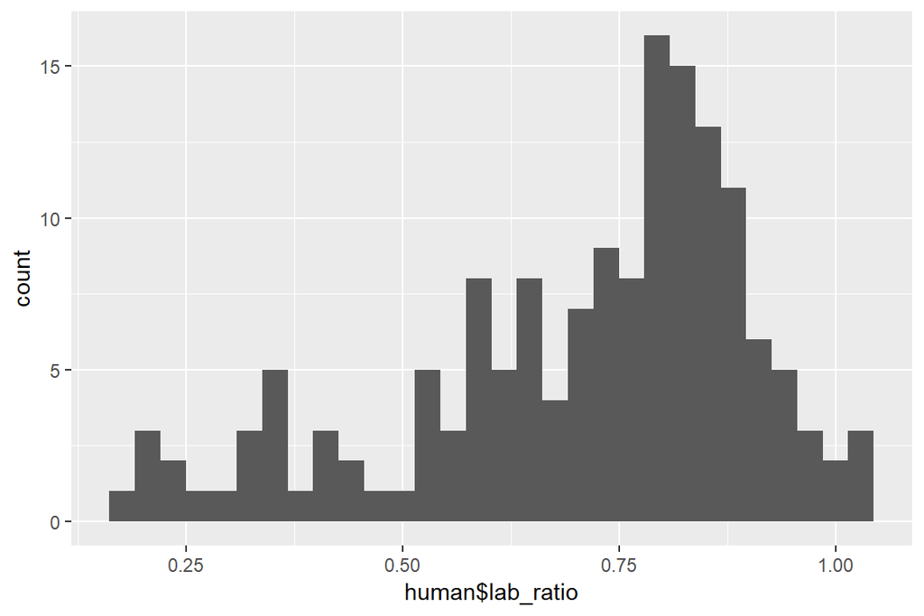

```r
ggplot(data = human, aes(human$lab_ratio)) + geom_histogram()
```

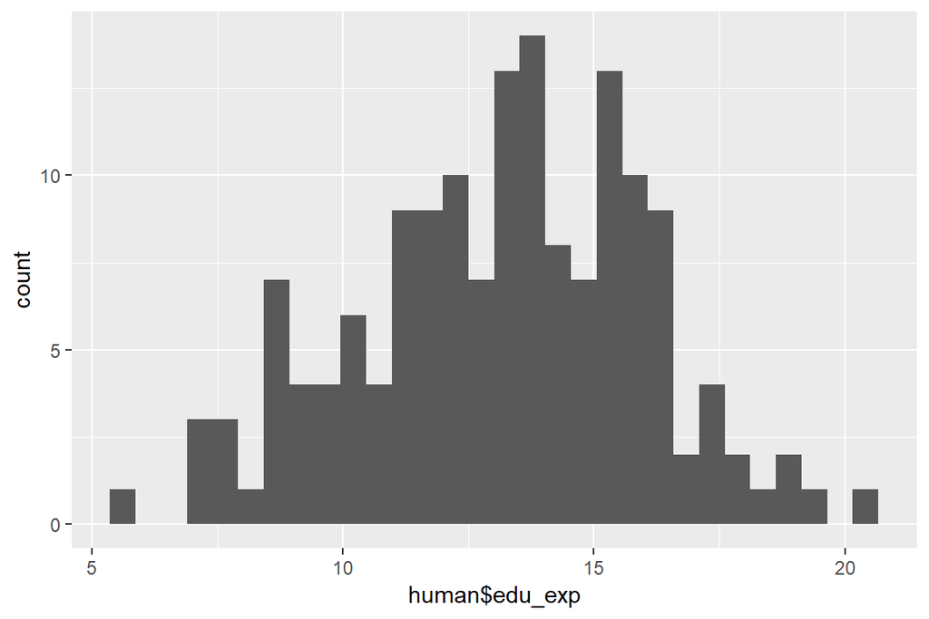

```r
ggplot(data = human, aes(human$edu_exp)) + geom_histogram()
```

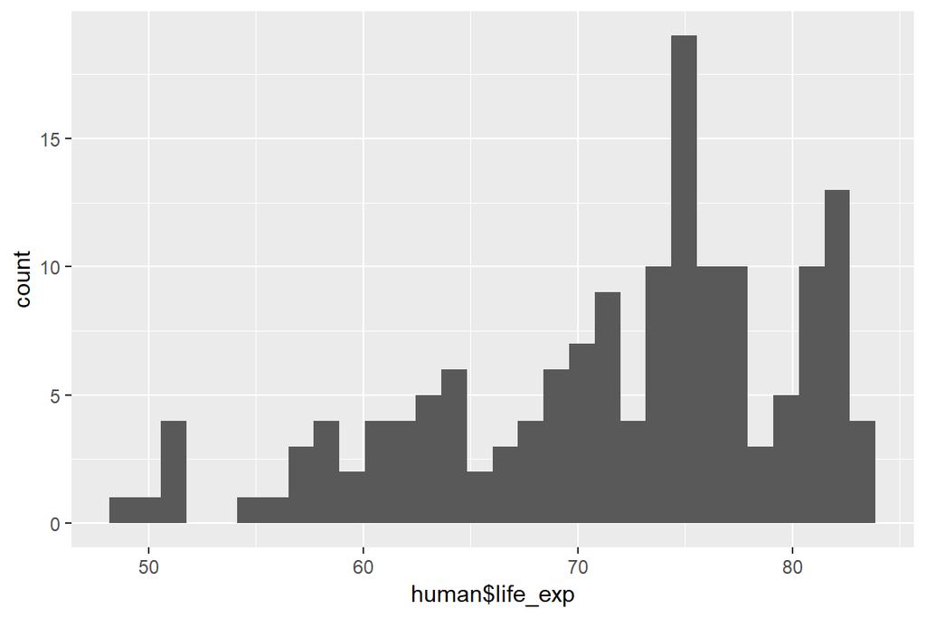

```r
ggplot(data = human, aes(human$life_exp)) + geom_histogram()
```

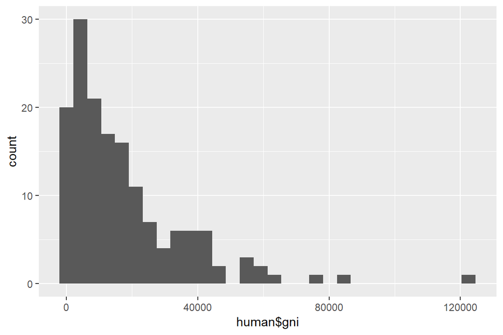

```r
ggplot(data = human, aes(human$gni)) + geom_histogram()
```

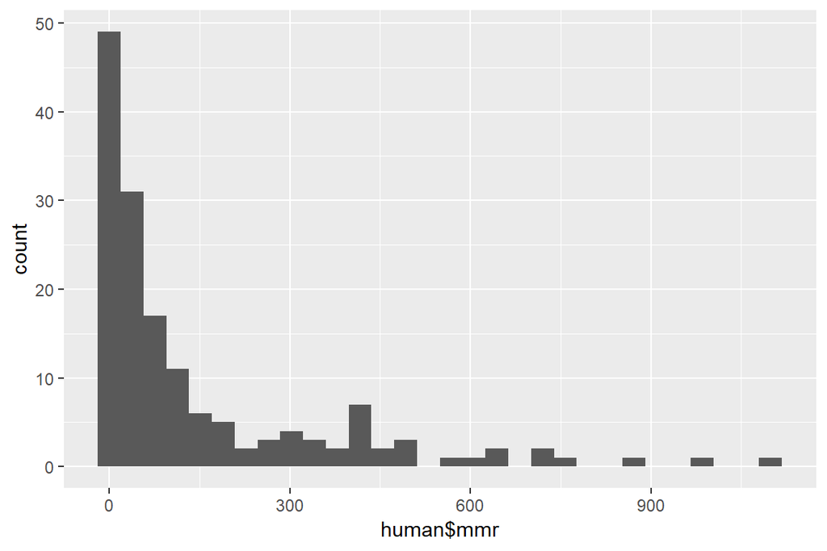

```r
ggplot(data = human, aes(human$mmr)) + geom_histogram()
```

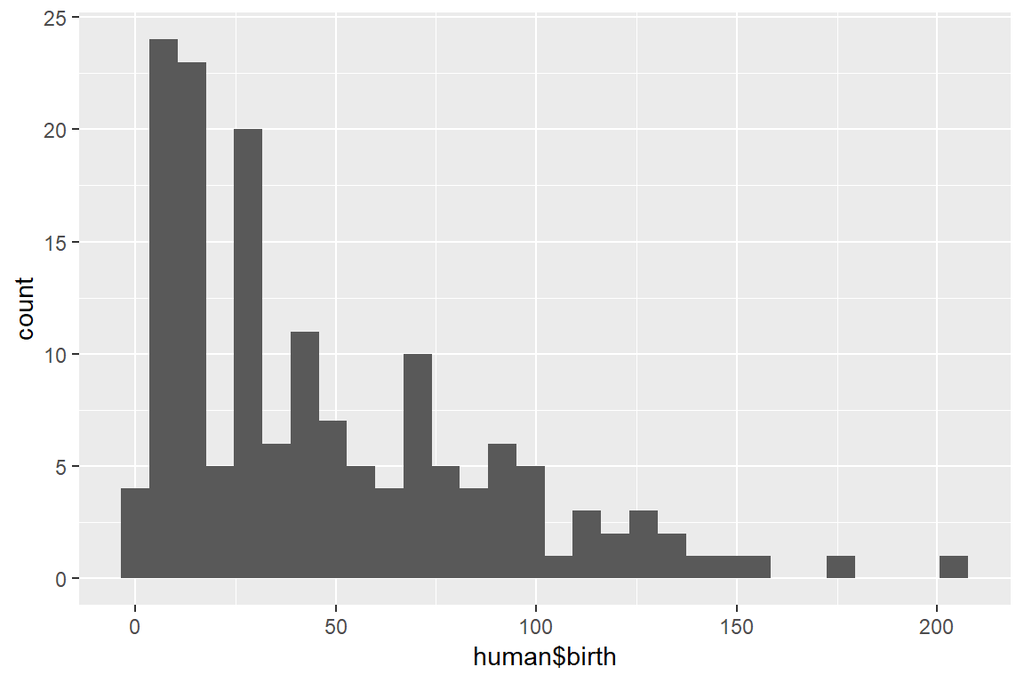

```r
ggplot(data = human, aes(human$birth)) + geom_histogram()
```

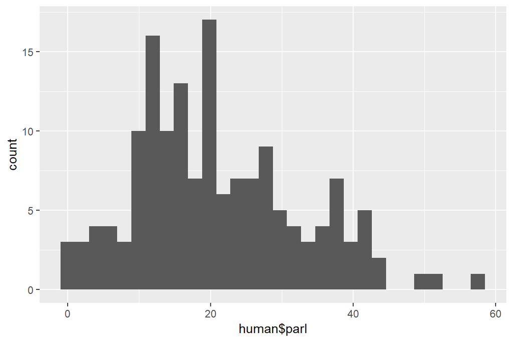

```r
ggplot(data = human, aes(human$parl)) + geom_histogram()
```

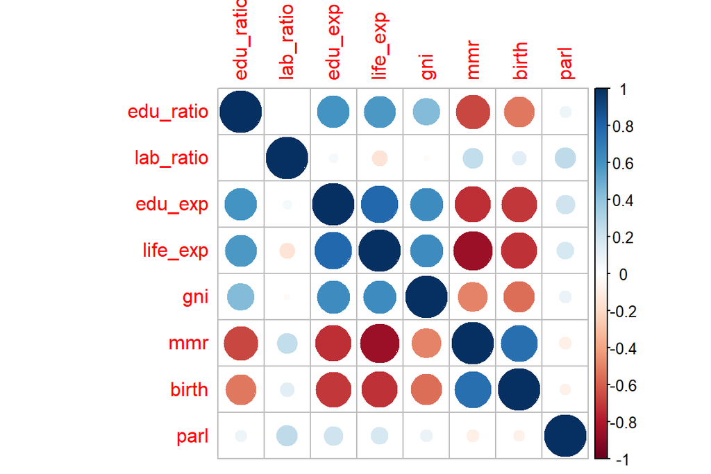

```r
corrplot(cor(human), method = "circle")
```

Now we can move on to actual dimensional reduction to see how we can impact the data.

### PCA

First we are going to perform the PCA on the unstandardized data to see how it works. We will perform the PCA and print the summary of it. We also make a biplot to see how PCA looks like when visualized.

```r
pca_human <- prcomp(human)
summ <- summary(pca_human)
summ
```

```
## Importance of components:
##                              PC1      PC2   PC3   PC4   PC5   PC6    PC7
## Standard deviation     1.854e+04 185.5219 25.19 11.45 3.766 1.566 0.1912
## Proportion of Variance 9.999e-01   0.0001  0.00  0.00 0.000 0.000 0.0000
## Cumulative Proportion  9.999e-01   1.0000  1.00  1.00 1.000 1.000 1.0000
##                           PC8
## Standard deviation     0.1591
## Proportion of Variance 0.0000
## Cumulative Proportion  1.0000
```

```r
pr <- round(100 * summ$importance[2,], digits = 1)
pr
```

```
## PC1 PC2 PC3 PC4 PC5 PC6 PC7 PC8
## 100   0   0   0   0   0   0   0
```

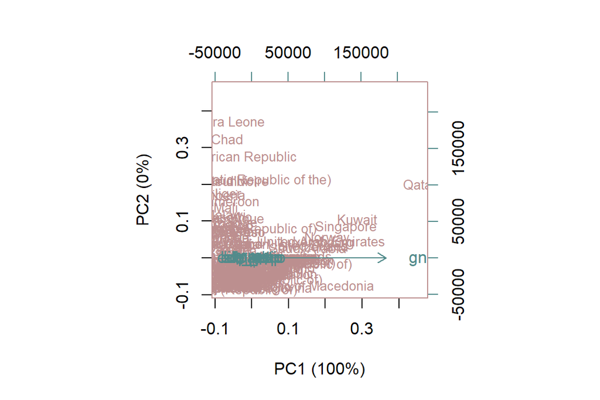

```r
lab <- paste0(names(pr), " (", pr, "%)")
biplot(pca_human, cex = c(0.8, 1), col = c("rosybrown", "darkslategray4"), xlab = lab[1], ylab = lab[2])
```

Let’s first look at the summary. Standard deviation tells us how much variance is associated in each principle component and the others are the proportional values. We can clearly see that the PC1 captures pretty much all the deviation since its value in the last row is 100. It seems a little bit weird that the values are not distributed any better between PCs. I can tell one reason right away: we did not standardize our data. PCA is really sensitive to variables that have large range so it assumes that the ones with large scale has actually the greatest variance. If we take a look at the biplot we can see that the longest arrow (which is actually really long compared to others) belongs to the variable `gni`. **And** when looking at the min and max values from the summary we made when introducing the dataset, we can see that `gni` has clearly the largest variance since it can get values from 581 to 123124. This method is pretty much useless to this data unless we do the standardization so that our variables are on a same scale.

Here is a summary of the dataset after standardization;

```r
human_scaled <- as.data.frame(scale(human))
summary(human_scaled)
```

```
##    edu_ratio         lab_ratio          edu_exp           life_exp
##  Min.   :-2.8189   Min.   :-2.6247   Min.   :-2.7378   Min.   :-2.7188
##  1st Qu.:-0.5233   1st Qu.:-0.5484   1st Qu.:-0.6782   1st Qu.:-0.6425
##  Median : 0.3503   Median : 0.2316   Median : 0.1140   Median : 0.3056
##  Mean   : 0.0000   Mean   : 0.0000   Mean   : 0.0000   Mean   : 0.0000
##  3rd Qu.: 0.5958   3rd Qu.: 0.7350   3rd Qu.: 0.7126   3rd Qu.: 0.6717
##  Max.   : 2.6646   Max.   : 1.6632   Max.   : 2.4730   Max.   : 1.4218
##       gni               mmr              birth              parl
##  Min.   :-0.9193   Min.   :-0.6992   Min.   :-1.1325   Min.   :-1.8203
##  1st Qu.:-0.7243   1st Qu.:-0.6496   1st Qu.:-0.8394   1st Qu.:-0.7409
##  Median :-0.3013   Median :-0.4726   Median :-0.3298   Median :-0.1403
##  Mean   : 0.0000   Mean   : 0.0000   Mean   : 0.0000   Mean   : 0.0000
##  3rd Qu.: 0.3712   3rd Qu.: 0.1932   3rd Qu.: 0.6030   3rd Qu.: 0.6127
##  Max.   : 5.6890   Max.   : 4.4899   Max.   : 3.8344   Max.   : 3.1850
```

Now the deviation between different variables should be on the same scale so the differences are actually comparable.

Let’s try the PCA again but with the standardized data and see if it had any impact:

```r
pca_human_s <- prcomp(human_scaled)
summ_s <- summary(pca_human_s)
summ_s
```

```
## Importance of components:
##                           PC1    PC2     PC3     PC4     PC5     PC6
## Standard deviation     2.0708 1.1397 0.87505 0.77886 0.66196 0.53631
## Proportion of Variance 0.5361 0.1624 0.09571 0.07583 0.05477 0.03595
## Cumulative Proportion  0.5361 0.6984 0.79413 0.86996 0.92473 0.96069
##                            PC7     PC8
## Standard deviation     0.45900 0.32224
## Proportion of Variance 0.02634 0.01298
## Cumulative Proportion  0.98702 1.00000
```

```r
pr_s <- round(100 * summ_s$importance[2,], digits = 1)
pr_s
```

```
##  PC1  PC2  PC3  PC4  PC5  PC6  PC7  PC8
## 53.6 16.2  9.6  7.6  5.5  3.6  2.6  1.3
```

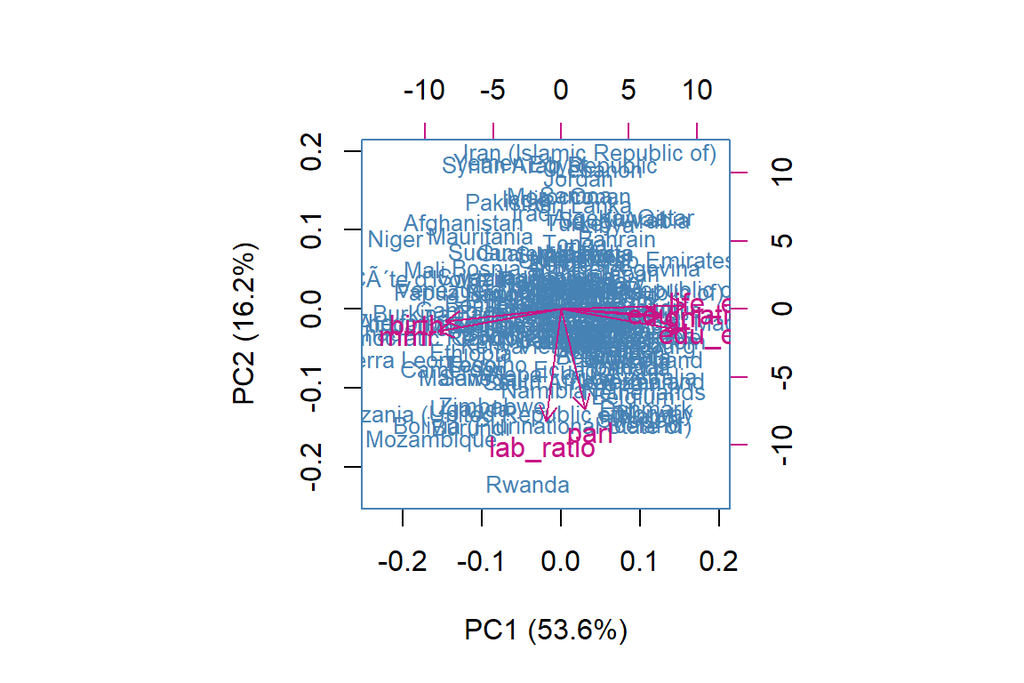

```r
lab_s <- paste0(names(pr_s), " (", pr_s, "%)")
biplot(pca_human_s, cex = c(0.8, 1), col = c("steelblue", "mediumvioletred"), xlab = lab_s[1], ylab = lab_s[2])
```

This looks **much** better! So the standardization worked. Now all the variance is not associated only in one PC but the others as well. Over half is still on the first one though (53.6). Now approximately 70% of the variance of the 8 variables is captured in the two principle components. These two components are visualized in the biplot. All the observations are placed on the scatterplot to see how they are located next to the PCs. The pink arrows are the variables from our dataset. The angles between two arrows or between an arrow and either x or y axis represent correlations between these objects. The smaller the angle, the higher the *positive* correlation. So for example `birth` and `mmr` are really close to each others which means that they have a strong positive correlation. This was actually also able to notice from the correlation matrix we made earlier. Other variables that also correlate strongly are `gni` and `edu_ratio`. We can also see that for example `life_exp` is contributing the PC1 since it is pointing to same direction. Meanwhile `lab_ratio` and `parl` are pointing downward which means that they are contributing PC2.

We actually made earlier some analysis about these phenomena and their relationships but we can talk about them a little more. As we earlier stated, it looks like that countries that have lower life expectancy tend to have higher MMr and also higher birth rate. Also the people from these countries have lower educational level and are apparently more poor since the GNI is also lower in them. From the plot we can see that examples from these countries are Sierra Leone and Tanzania since they are on the left side of the plot. On the other side we have for example Denmark that is much wealthier country where both men and women have more years in education. In Denmark people have high life expectancy but also less children compared to people in Sierra Leone for example. One thing that we are also interested in is that Rwanda is a little bit separated from others and it is located in the bottom of the plot - which is the place were `parl` is pointing at. `parl` means the ratio of men and women in the country’s parliament. With quick checking we can see that Rwanda is the country with most women in their parliament! So apparently ratio of men and women in parliament or labour ratio do not have much to do with country’s economy, education or health factors.

PC1 is associated with six variables while PC2 with two which might explain why PC1 has so high percentage. It is fascinating to notice how much information we can get from a single plot. It would be even more interesting to see how the observations would look like on the plot after grouping, but that is not the main point in this exercise.

I think this is enough analysis for the PCA so we can move on to MCA.

### MCA

For the multiple correspondence analysis we are using different data. It it the `tea` data from the `FactoMineR` package in R. Here is the first glance of the data:

```r
library(FactoMineR)
data(tea)

str(tea)
```

```
## 'data.frame':    300 obs. of  36 variables:
##  $ breakfast       : Factor w/ 2 levels "breakfast","Not.breakfast": 1 1 2 2 1 2 1 2 1 1 ...
##  $ tea.time        : Factor w/ 2 levels "Not.tea time",..: 1 1 2 1 1 1 2 2 2 1 ...
##  $ evening         : Factor w/ 2 levels "evening","Not.evening": 2 2 1 2 1 2 2 1 2 1 ...
##  $ lunch           : Factor w/ 2 levels "lunch","Not.lunch": 2 2 2 2 2 2 2 2 2 2 ...
##  $ dinner          : Factor w/ 2 levels "dinner","Not.dinner": 2 2 1 1 2 1 2 2 2 2 ...
##  $ always          : Factor w/ 2 levels "always","Not.always": 2 2 2 2 1 2 2 2 2 2 ...
##  $ home            : Factor w/ 2 levels "home","Not.home": 1 1 1 1 1 1 1 1 1 1 ...
##  $ work            : Factor w/ 2 levels "Not.work","work": 1 1 2 1 1 1 1 1 1 1 ...
##  $ tearoom         : Factor w/ 2 levels "Not.tearoom",..: 1 1 1 1 1 1 1 1 1 2 ...
##  $ friends         : Factor w/ 2 levels "friends","Not.friends": 2 2 1 2 2 2 1 2 2 2 ...
##  $ resto           : Factor w/ 2 levels "Not.resto","resto": 1 1 2 1 1 1 1 1 1 1 ...
##  $ pub             : Factor w/ 2 levels "Not.pub","pub": 1 1 1 1 1 1 1 1 1 1 ...
##  $ Tea             : Factor w/ 3 levels "black","Earl Grey",..: 1 1 2 2 2 2 2 1 2 1 ...
##  $ How             : Factor w/ 4 levels "alone","lemon",..: 1 3 1 1 1 1 1 3 3 1 ...
```

[output cut: 22 more lines]

```r
summary(tea)
```

```
##          breakfast           tea.time          evening          lunch
##  breakfast    :144   Not.tea time:131   evening    :103   lunch    : 44
##  Not.breakfast:156   tea time    :169   Not.evening:197   Not.lunch:256
##
##
##
##
##
##         dinner           always          home           work
##  dinner    : 21   always    :103   home    :291   Not.work:213
##  Not.dinner:279   Not.always:197   Not.home:  9   work    : 87
##
##
##
##
##
##         tearoom           friends          resto          pub
##  Not.tearoom:242   friends    :196   Not.resto:221   Not.pub:237
##  tearoom    : 58   Not.friends:104   resto    : 79   pub    : 63
##
##
##
##
##
##         Tea         How           sugar                     how
##  black    : 74   alone:195   No.sugar:155   tea bag           :170
##  Earl Grey:193   lemon: 33   sugar   :145   tea bag+unpackaged: 94
##  green    : 33   milk : 63                  unpackaged        : 36
##                  other:  9
##
##
##
##                   where                 price          age        sex
##  chain store         :192   p_branded      : 95   Min.   :15.00   F:178
##  chain store+tea shop: 78   p_cheap        :  7   1st Qu.:23.00   M:122
##  tea shop            : 30   p_private label: 21   Median :32.00
##                             p_unknown      : 12   Mean   :37.05
##                             p_upscale      : 53   3rd Qu.:48.00
##                             p_variable     :112   Max.   :90.00
##
```

[output cut: 25 more lines]

```
##  feminine    :129   Not.sophisticated: 85   No.slimming:255
##  Not.feminine:171   sophisticated    :215   slimming   : 45
##
##
##
##
##
##         exciting          relaxing              effect.on.health
##  exciting   :116   No.relaxing:113   effect on health   : 66
##  No.exciting:184   relaxing   :187   No.effect on health:234
##
##
##
##
##
```

The dataset has 36 variables and 300 observations. All of the variables except age are categorical variables and they are about tea consumption. There are also some basic information of the respondents. Since there are so many variables we are not going to use all of them. I’ll choose eight variables like we had in the previous exercise. Those variables are `breakfast`, `tea.time`, `evening`, `spirituality`, `healthy`, `sex`, `Sport` and `age` (the categorized one). Here is the summary of the variables we chose:

```r
keep_cols <- c("breakfast", "tea.time", "evening", "spirituality", "healthy", "sex", "Sport", "age_Q")
tea2 <- tea[, keep_cols]

str(tea2)
```

```
## 'data.frame':    300 obs. of  8 variables:
##  $ breakfast   : Factor w/ 2 levels "breakfast","Not.breakfast": 1 1 2 2 1 2 1 2 1 1 ...
##  $ tea.time    : Factor w/ 2 levels "Not.tea time",..: 1 1 2 1 1 1 2 2 2 1 ...
##  $ evening     : Factor w/ 2 levels "evening","Not.evening": 2 2 1 2 1 2 2 1 2 1 ...
##  $ spirituality: Factor w/ 2 levels "Not.spirituality",..: 1 1 1 2 2 1 1 1 1 1 ...
##  $ healthy     : Factor w/ 2 levels "healthy","Not.healthy": 1 1 1 1 2 1 1 1 2 1 ...
##  $ sex         : Factor w/ 2 levels "F","M": 2 1 1 2 2 2 2 1 2 2 ...
##  $ Sport       : Factor w/ 2 levels "Not.sportsman",..: 2 2 2 1 2 2 2 2 2 1 ...
##  $ age_Q       : Factor w/ 5 levels "15-24","25-34",..: 3 4 4 1 4 1 3 3 3 3 ...
```

```r
summary(tea2)
```

```
##          breakfast           tea.time          evening
##  breakfast    :144   Not.tea time:131   evening    :103
##  Not.breakfast:156   tea time    :169   Not.evening:197
##
##
##
##            spirituality        healthy    sex               Sport
##  Not.spirituality:206   healthy    :210   F:178   Not.sportsman:121
##  spirituality    : 94   Not.healthy: 90   M:122   sportsman    :179
##
##
##
##    age_Q
##  15-24:92
##  25-34:69
##  35-44:40
##  45-59:61
##  +60  :38
```

Now we have only categorical variables that have either two or five categories. Let’s make some plots to see how the variables bistribute so that we don’t have to look at the summary statistics only:

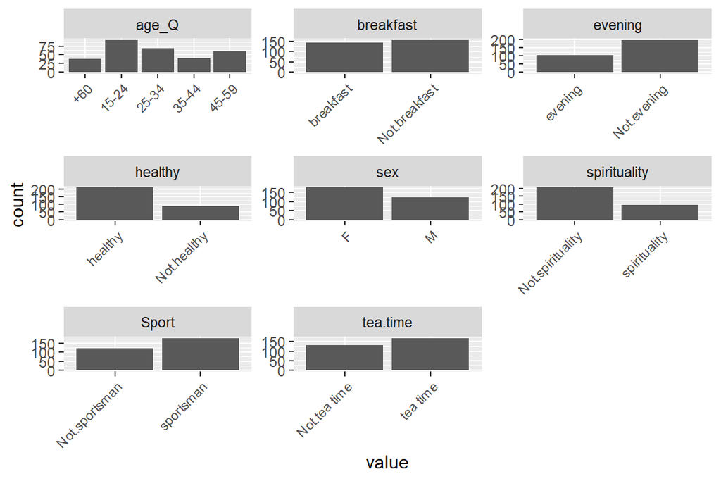

```r
library(dplyr)
library(tidyr)

gather(tea2) %>% ggplot(aes(value)) + facet_wrap("key", scales = "free") + geom_bar() + theme(axis.text.x = element_text(angle = 45, hjust = 1, size = 8))
```

Okay so we can see that the biggest class in age is 15-24 years old and the second one is 25-34 years old. The breakfast variable has pretty much same amount of values in both classes while others have bigger differnce between classes. What we actually want to see is that if there are any correlation between any variables and if the observations are grouped in some way. So actually the same thing as in PCA except that the data is categorical this time.

Let’s just perform the MCA analysis:

```r
mca_tea <- MCA(tea2, graph = FALSE)

summary(mca_tea)
```

```
##
## Call:
## MCA(X = tea2, graph = FALSE)
##
##
## Eigenvalues
##                        Dim.1   Dim.2   Dim.3   Dim.4   Dim.5   Dim.6
## Variance               0.198   0.163   0.152   0.141   0.127   0.126
## % of var.             14.404  11.828  11.020  10.260   9.237   9.155
## Cumulative % of var.  14.404  26.232  37.251  47.511  56.748  65.903
##                        Dim.7   Dim.8   Dim.9  Dim.10  Dim.11
## Variance               0.115   0.107   0.094   0.088   0.064
## % of var.              8.352   7.818   6.820   6.420   4.687
## Cumulative % of var.  74.255  82.073  88.893  95.313 100.000
##
## Individuals (the 10 first)
##                     Dim.1    ctr   cos2    Dim.2    ctr   cos2    Dim.3
## 1                |  0.197  0.066  0.025 |  0.637  0.832  0.262 | -0.208
## 2                | -0.022  0.001  0.000 |  0.384  0.301  0.130 | -0.713
## 3                | -0.174  0.051  0.025 | -0.278  0.158  0.063 | -0.183
## 4                |  0.185  0.058  0.026 |  0.104  0.022  0.008 |  0.363
## 5                |  0.604  0.615  0.197 | -0.193  0.076  0.020 | -0.188
## 6                |  0.454  0.347  0.206 |  0.132  0.036  0.017 | -0.101
## 7                | -0.137  0.031  0.013 |  0.428  0.376  0.123 | -0.288
## 8                | -0.319  0.171  0.066 | -0.262  0.140  0.044 |  0.238
## 9                | -0.042  0.003  0.001 |  0.119  0.029  0.008 | -0.121
## 10               |  0.079  0.010  0.003 |  0.409  0.344  0.092 |  0.326
##                     ctr   cos2
## 1                 0.095  0.028 |
## 2                 1.118  0.449 |
## 3                 0.074  0.027 |
## 4                 0.290  0.100 |
## 5                 0.078  0.019 |
## 6                 0.022  0.010 |
## 7                 0.183  0.056 |
## 8                 0.124  0.037 |
## 9                 0.032  0.008 |
## 10                0.233  0.058 |
##
## Categories (the 10 first)
```

[output cut: 18 more lines]

```
## Not.spirituality   0.052   3.942 |  -0.099   0.558   0.022  -2.540 |
## spirituality       0.052  -3.942 |   0.217   1.222   0.022   2.540 |
## healthy            0.209   7.904 |  -0.157   1.418   0.057  -4.139 |
## Not.healthy        0.209  -7.904 |   0.366   3.309   0.057   4.139 |
##
## Categorical variables (eta2)
##                    Dim.1 Dim.2 Dim.3
## breakfast        | 0.002 0.026 0.467 |
## tea.time         | 0.348 0.112 0.016 |
## evening          | 0.072 0.291 0.064 |
## spirituality     | 0.000 0.052 0.022 |
## healthy          | 0.024 0.209 0.057 |
## sex              | 0.405 0.142 0.017 |
## Sport            | 0.235 0.039 0.306 |
## age_Q            | 0.498 0.431 0.264 |
```

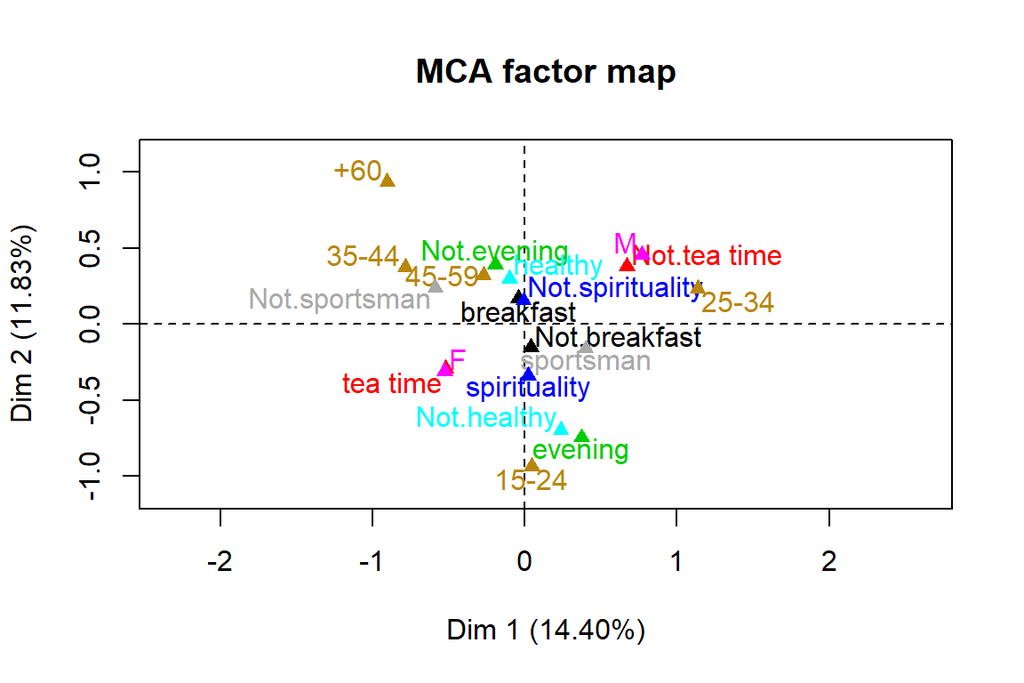

```r
plot(mca_tea, invisible = c("ind"), habillage = "quali")
```

The summary and plot differs a bit from PCA. From Eigenvalues in the summary we can see the variances associated to each dimension and the percentages. The variances decrease slowly while dimensions increase. Next we have the individuals and their coordinates. If we look at the categories, some of the values are clearly greater than 1.96 or less than -1.96 which indicates that the coordinate is significantly different from zero. Categorical variables tell the correlation between variables and dimensions. The closer the value is to 1, the greater correlation. None of the values is not even greater than 0.5, the largest value is the one with `age_Q` and `Dim.1`. So apparently there are no significant correlations. There are a lot values to look at so maybe it is better to move on to the plot so that we could get a clearer image about the variables.

So the MCA factor map shows the possible values/classes of each variable plotted in the map where Dim 1 is the x axis and Dim 2 the y axis. What we are interested in is the distances of the groups from each other - the smaller the distance, the more similar the categories are. For example we can see that the *no tea time* -group is pretty close to the male-group. Also categories *not healthy* and *evening* are pretty close to each other. This means that the ones that have answered the ‘not healthy’ option are the ones that prefer to drink tea in the evening. We can also see that the +60 group is quite far from any of the other categories which would mean that there are no really any other variables that could be associate to seniors.

We could have tried to use other variables to see if there would have been any better correlations between them and create a bit better profiling. However, this also gave us some information, even though these two dimensions capture only fourth of the variance of the variables.

## Week 6: Analysis of longitudal data

Last week’s task is to analyze two different datasets that are from longitudal studies. We are going to use different methods to get some possibly interesting results from the data. First we are going to make some graphical displays and summary measure approach. After that we’ll use linear mixed effects models. The goal of this report is to show how longitudal data can be examined and what kind of difficulties we might have to face with this kind of data.

### The data

As said earlier, we are going to use two different datasets that are found from MABS. The first one is called [RATS](https://raw.githubusercontent.com/KimmoVehkalahti/MABS/master/Examples/data/rats.txt) which is collected for a study that examines the impact of different diets on weight. Test subjects were three different groups of rats. The study took over nine weeks and the rats were weighted once every week (except one week they were weighted twice).

The second one is [BPRS](https://raw.githubusercontent.com/KimmoVehkalahti/MABS/master/Examples/data/BPRS.txt) data that contains information of 40 men. The aim of the study was to find out if there was any difference between two different treatments. The variable that was measured was a brief psychiatric rating scale (BPRS). Test subject were scaled right before the study and after that once a week for eight weeks. The score measures 18 different symptoms that can be associated to schizophrenia. More information about these datasets and the methods that are used can be found from [here](https://mooc.helsinki.fi/pluginfile.php/29659/course/section/2208/MABS4IODS-Part6.pdf).

### Graphical Displays and Summary Measure Approach

#### RATS data

We are going to first analyze the RATS data. I already explained a little bit the background of the dataset but let’s take a quick look of the structure of the data and what the variables look like. The original data was in wide form but it was changed into long form and few datatypes were changed. After loading the dataset the summary of ot looks like this:

```r
load("data/RATSL.rdata")
rats <- rats_l # I'll rename the data as rats just to make it easier. This is still the longitudal data.

str(rats)
```

```
## 'data.frame':    176 obs. of  4 variables:
##  $ ID    : Factor w/ 16 levels "1","2","3","4",..: 1 2 3 4 5 6 7 8 9 10 ...
##  $ Group : Factor w/ 3 levels "1","2","3": 1 1 1 1 1 1 1 1 2 2 ...
##  $ weight: int  240 225 245 260 255 260 275 245 410 405 ...
##  $ day   : int  1 1 1 1 1 1 1 1 1 1 ...
```

```r
summary(rats)
```

```
##        ID      Group      weight           day
##  1      : 11   1:88   Min.   :225.0   Min.   : 1.00
##  2      : 11   2:44   1st Qu.:267.0   1st Qu.:15.00
##  3      : 11   3:44   Median :344.5   Median :36.00
##  4      : 11          Mean   :384.5   Mean   :33.55
##  5      : 11          3rd Qu.:511.2   3rd Qu.:50.00
##  6      : 11          Max.   :628.0   Max.   :64.00
##  (Other):110
```

#### Graphical displays

We are now enough familiar with the data so that we can make some visalizations of it to see how variables distribute. This will give us more information about the observations and what kind of methods and tests would be most suitable. Let’s first take a look of a line charts that shows all the rats in their own lines so that we can see how an individual observation distributes:

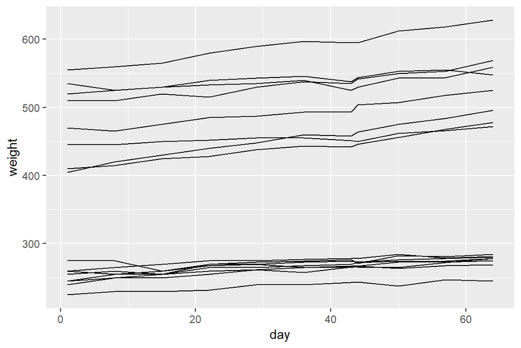

```r
library(ggplot2)

ggplot(rats, aes(x = day, y = weight, group = ID)) +
  geom_line()
```

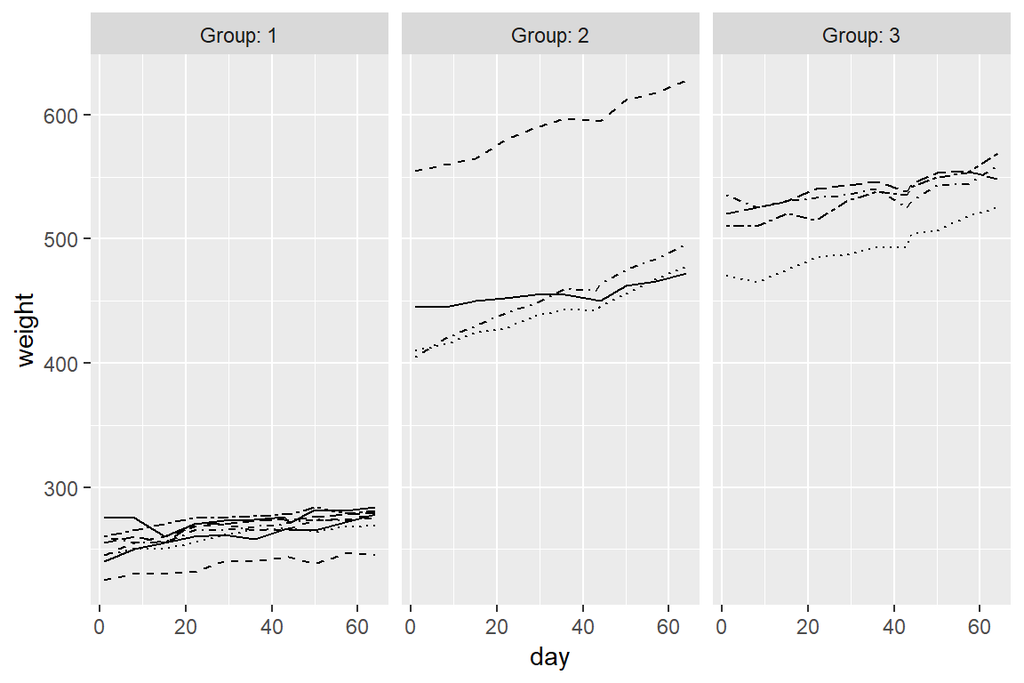

```r
ggplot(rats, aes(x = day, y = weight, linetype = ID)) +
  geom_line() +
  scale_linetype_manual(values = rep(1:10, times = 4)) +
  facet_grid(. ~ Group, labeller = label_both) +
  theme(legend.position = "none") +
  scale_y_continuous(limits = c(min(rats$weight), max(rats$weight)))
```

In the first plot we can see the progress of all the rats’ weights. We can see that approximately half of the rats are much lighter than others. The lightest rats are less than 300 grams through the whole experiment while the heavier ones weight more than 400 grams, the heaviest weights at the end of the experiment more than 600 grams - almost three times more than the lightest one. There seems to be happening at least a slight increase in weight with almost all rats. The increase looks a bit more noticeable on rats with higher starting weight.

The second figure is the same as the first one, except that in this one the rats are grouped by the `Group` variable. Each group has their own plot so that we can see how the groups are distributed. Apparently all the rats that had lower weight belong in the group 1. Especially one is a little bit separated from others and is quite small compared to others, though I would not necessarily call it an outlier observations in the group 2 is much heavier than others. Its line can be seen right on top of the plot in the middle. It can be a little bit tricky because it can have impact on whole group’s statistics. Such extreme values tend to give biased results for example when calculating mean values. There is also one observation in the group 3 that is a little bit separated from others, but I don’t see it as a problem.

These plots are a little bit difficult to interpret since there are a lot of observations to look at. It it hard to look at certain observations because the lines are so close to each other. However, we got some information about the groups and how weights change.

Let’s quick take a look at another graphs that will show us how means of the groups differ from each other. Before that we need little bit change our data. We’ll make a new dataset called `mean_data` just for the means so that we can plot the line charts correctly. Here’s a line chart that shows how the mean of weights in different groups change within the time period and a boxplot of the groups:

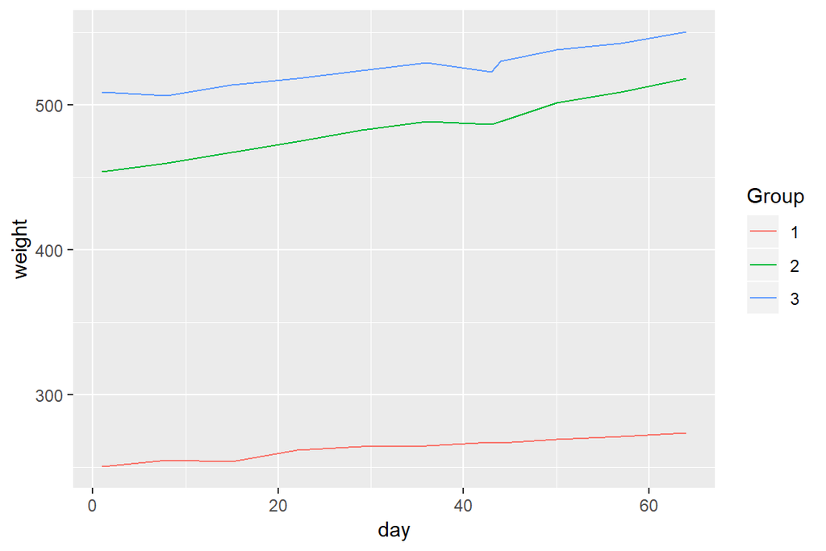

```r
library(dplyr)

mean_data <- group_by(rats, Group, day) %>%
             summarise(weight = mean(weight))

ggplot(mean_data, aes(x = day, y = weight, colour = Group)) + geom_line()
```

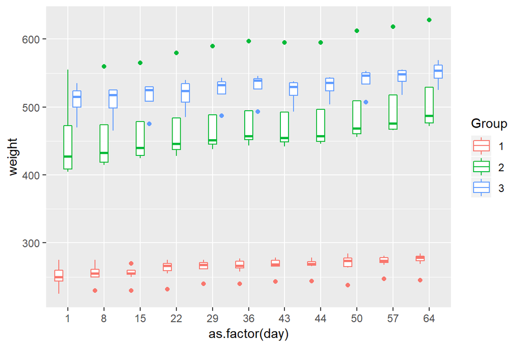

```r
ggplot(rats, aes(x = as.factor(day), y = weight, colour = Group)) + geom_boxplot()
```

So as we can see from the plots, the means of the weights in these three groups are completely different. It is because the starting weights of rats are not the same at all. We could do the statistical testing to see if the starting weight has a significant impact but we’ll skip that. If we actually want to know that is there a difference between the diets and what kind of effect (or if there is such at all) the diets have on the rats we need to find a better measure than just mean like this. That is why we need to do some changes.

As we noticed earlier, the main issue is with the starting weights. If we’ll set the starting weights the same and then compare the changes that will happen, would that make a difference? Yes. That way the groups and individuals would be more comparable. So what we are going to do is that we’ll make a new dataset that is the same as our original `rats` except that we’ll make a variable called `change` which measures how much the weight of the rat has changed compared to the starting point. The starting point is set to 0 to each rat. Here’s the summary of the new `rats_c` data and the grouped line plot we did earlier:

```r
rats_c <- rats %>%
  group_by(day) %>%
  mutate(change = (weight - rats$weight[rats$day == 1])) %>%
  ungroup()

summary(rats_c)
```

```
##        ID      Group      weight           day            change
##  1      : 11   1:88   Min.   :225.0   Min.   : 1.00   Min.   :-15.00
##  2      : 11   2:44   1st Qu.:267.0   1st Qu.:15.00   1st Qu.:  5.00
##  3      : 11   3:44   Median :344.5   Median :36.00   Median : 17.00
##  4      : 11          Mean   :384.5   Mean   :33.55   Mean   : 18.55
##  5      : 11          3rd Qu.:511.2   3rd Qu.:50.00   3rd Qu.: 25.00
##  6      : 11          Max.   :628.0   Max.   :64.00   Max.   : 91.00
##  (Other):110
```

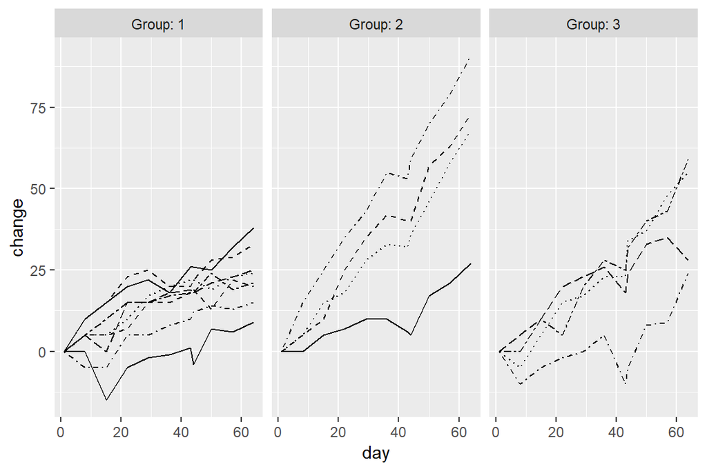

```r
ggplot(rats_c, aes(x = day, y = change, linetype = ID)) +
  geom_line() +
  scale_linetype_manual(values = rep(1:10, times = 4)) +
  facet_grid(. ~ Group, labeller = label_both) +
  theme(legend.position = "none") +
  scale_y_continuous(limits = c(min(rats_c$change), max(rats_c$change)))
```

Now we can see how the weights of rats change. We can see that the plots start from the same point. It looks like the change is quite rapid in the group 2 and more settle in group 1. Group 3 is somewhere in the middle. There are some observations that have temporary decreases but all the rats have higher weight at the end of the study.

Here we can see the grouped means of the changes of the weights plotted:

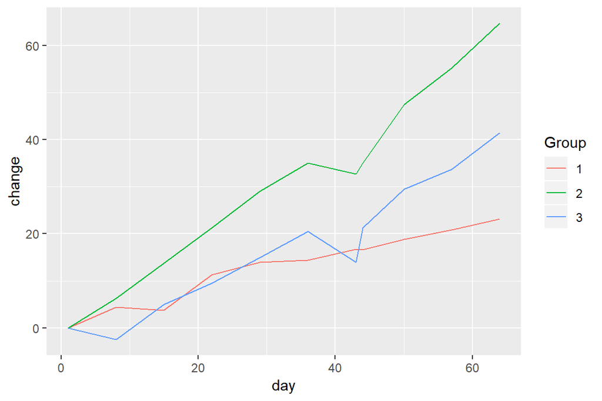

```r
mean_rats_c <- group_by(rats_c, Group, day) %>%
             summarise(change = mean(change))

ggplot(mean_rats_c, aes(x = day, y = change, colour = Group)) + geom_line()
```

As we noticed earlier, the weight gain is fastest on group 2 and slowest in group 1. The gain seems to be at the end in group 2 almost trice the gain in group 1.

Now that we have done quite a lot of visualizing, we can move on to testing and analyzing!

#### Summary measure approach and testing

We already have made a notice that the groups seems to be a little bit different from each other, especially groups 1 and 2, but it is always nice to make proper tests. Before that we’ll make one more plot! We’ll make a boxplot to visualize the distributions of the group means so that we’ll understand better what we are going to test:

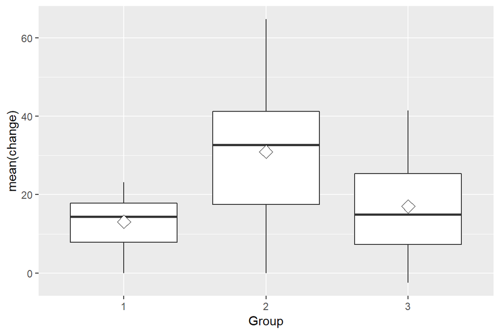

```r
ggplot(mean_rats_c, aes(x = Group, y = change)) +
  geom_boxplot() +
  stat_summary(fun.y = "mean", geom = "point", shape = 23, size = 4, fill = "white") +
  scale_y_continuous(name = "mean(change)")
```

So now we can see how much the means of weight changes differ from each other between groups (we saw it from other plots as well, but I think this shows it the best). Groups 1 and 3 have pretty similar lower parts but after the mean line the range of group 3 goes higher.

We are going to test the groups first with ANOVA and then with t-test. Briefly explained, ANOVA is used to compare the groups together and tell if there is a significant difference between them. So the null hypothesis would be that there is no difference between these three groups. ANOVA does not tell which groups differ from each other so we’ll use t-test to see if some of the groups differ and some don’t. First we’ll do the ANOVA:

```r
fit <- lm(change ~ Group, data = mean_rats_c)

anova(fit)
```

```
## Analysis of Variance Table
##
## Response: change
##           Df Sum Sq Mean Sq F value  Pr(>F)
## Group      2 1936.8  968.39  4.4588 0.02017 *
## Residuals 30 6515.5  217.18
## ---
## Signif. codes:  0 '***' 0.001 '**' 0.01 '*' 0.05 '.' 0.1 ' ' 1
```

If we look at the p-value (`Pr(>F)`), it is less than 0.05 which indicates that with 95% confidence interval the groups differ from each other. It would mean that there is a difference between the diets the rats are having. Let’s take a look at the t-test results:

```r
t.test(change ~ Group, data = mean_rats_c[mean_rats_c$Group != 3,], var.equal = TRUE)
```

```
##
##  Two Sample t-test
##
## data:  change by Group
## t = -2.7728, df = 20, p-value = 0.01174
## alternative hypothesis: true difference in means is not equal to 0
## 95 percent confidence interval:
##  -31.302498  -4.424774
## sample estimates:
## mean in group 1 mean in group 2
##        13.09091        30.95455
```

```r
t.test(change ~ Group, data = mean_rats_c[mean_rats_c$Group != 2,], var.equal = TRUE)
```

```
##
##  Two Sample t-test
##
## data:  change by Group
## t = -0.82771, df = 20, p-value = 0.4176
## alternative hypothesis: true difference in means is not equal to 0
## 95 percent confidence interval:
##  -13.920676   6.011585
## sample estimates:
## mean in group 1 mean in group 3
##        13.09091        17.04545
```

```r
t.test(change ~ Group, data = mean_rats_c[mean_rats_c$Group != 1,], var.equal = TRUE)
```

```
##
##  Two Sample t-test
##
## data:  change by Group
## t = 1.8905, df = 20, p-value = 0.07327
## alternative hypothesis: true difference in means is not equal to 0
## 95 percent confidence interval:
##  -1.438187 29.256368
## sample estimates:
## mean in group 2 mean in group 3
##        30.95455        17.04545
```

This is interesting. This indicates that groups 1 and 2 are significantly different, but groups 1 and 3, *and* 2 and 3 aren’t. This indicates that the results of ANOVA would be against null hypothesis because of the difference between groups 1 and 2.

There are some issues when changing the data the way we did, because there can be information hidden under the starting weight. It is possible that the weight of a rat might correlate with the amount of weight gain or similar phenomena that might not get noticed. But I think that this was a good enough way to test the difference between the diets.

### Linear Mixed Effects Models

#### BPRS data

Next we are having the BPRS data and another method to investigate longitudinal data. We are already familiar what the BPRS data is measuring but as with previous dataset, we would like to know how this data is structured. Same kind of wrangling that was done to RATS data was also done to this data. What we interested in this time is that how well we can model these scores and to see the differences between treatments.

Here are the data structure and the summary of the `bprs` data:

```r
load("data/BPRSL.rdata")
bprs <- bprs_l

str(bprs)
```

```
## 'data.frame':    360 obs. of  4 variables:
##  $ treatment: Factor w/ 2 levels "1","2": 1 1 1 1 1 1 1 1 1 1 ...
##  $ subject  : Factor w/ 20 levels "1","2","3","4",..: 1 2 3 4 5 6 7 8 9 10 ...
##  $ score    : int  42 58 54 55 72 48 71 30 41 57 ...
##  $ week     : int  0 0 0 0 0 0 0 0 0 0 ...
```

```r
summary(bprs)
```

```
##  treatment    subject        score            week
##  1:180     1      : 18   Min.   :18.00   Min.   :0
##  2:180     2      : 18   1st Qu.:27.00   1st Qu.:2
##            3      : 18   Median :35.00   Median :4
##            4      : 18   Mean   :37.66   Mean   :4
##            5      : 18   3rd Qu.:43.00   3rd Qu.:6
##            6      : 18   Max.   :95.00   Max.   :8
##            (Other):252
```

This data has 4 variables and 360 observations. There are two treatment groups and 40 test subjects (20 in each treatment). The minimum score of all the scores is 18 and the maximum is 95, though we donät know that from which week these have been recorded and are they from same person.

#### Visualization

These are the same kind of plots we made earlier to the RATS data, that shows how the scores change through the eight-week time period with each individual. The first plot is for all of the observations and the second one is grouped by the treatment. They might look a bit messy but maybe we’ll get some information from them:

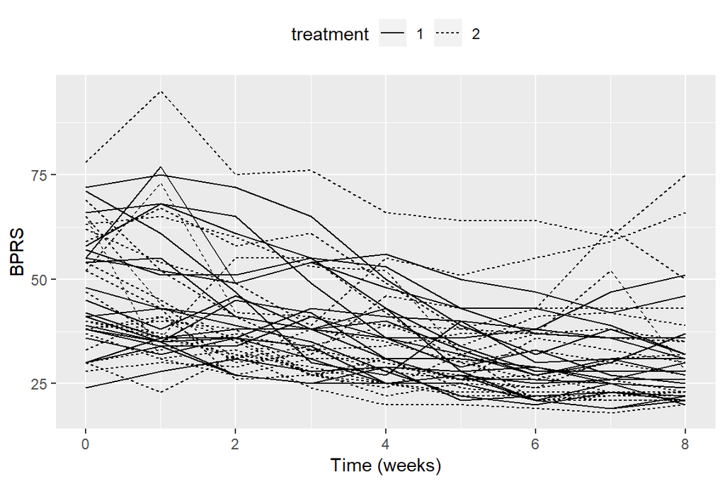

```r
library(ggplot2)

# number of ids needed
no_ids <- length(levels(bprs$treatment)) * length(levels(bprs$subject))
# set new unique ids
bprs$id <- rep(1:no_ids, nrow(bprs)/no_ids)

ggplot(bprs, aes(x = week, y = score, group = id)) +
  geom_line(aes(linetype = treatment)) +
  scale_x_continuous(name = "Time (weeks)", breaks = seq(0, 8, 2)) +
  scale_y_continuous(name = "BPRS") +
  theme(legend.position = "top")
```

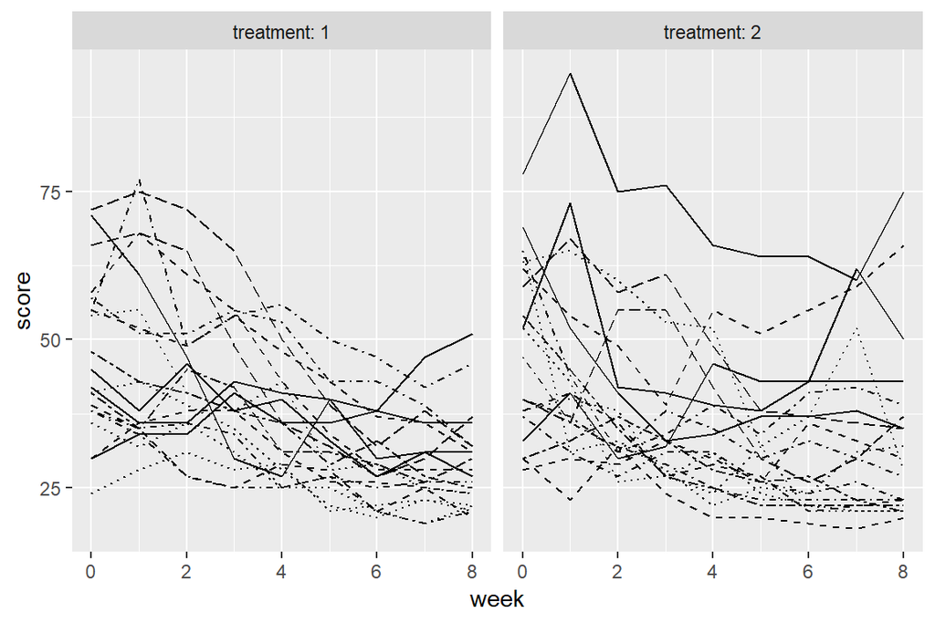

```r
ggplot(bprs, aes(x = week, y = score, linetype = subject)) +
  geom_line() +
  scale_linetype_manual(values = rep(1:10, times = 4)) +
  facet_grid(. ~ treatment, labeller = label_both) +
  theme(legend.position = "none") +
  scale_y_continuous(limits = c(min(bprs$score), max(bprs$score)))
```

Okay, they do look messy - especially the first one. We can see that there is a slight difference between groups. Most of the difference is because of the outlier and some rising lines and spikes in treatment group 2. It looks like overall the scores decrease from most of the test subjects, though there are some observations that seem to have higher score in the end of the study than before. However I would not necessarily say that there is a significant difference between these two groups - but it’s hard to say based on only this graph.

I’d like to find out what the means look like in the line chart so that we could get a bit clearer image of the groups:

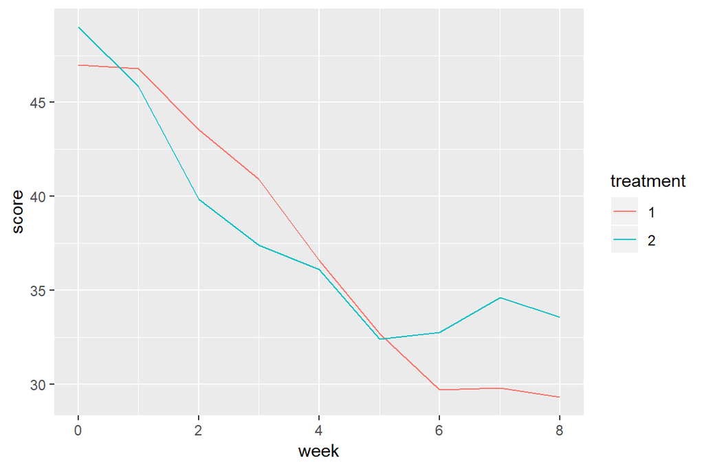

```r
mean_bprs <- group_by(bprs, treatment, week) %>%
             summarise(score = mean(score))

ggplot(mean_bprs, aes(x = week, y = score, colour = treatment)) + geom_line()
```

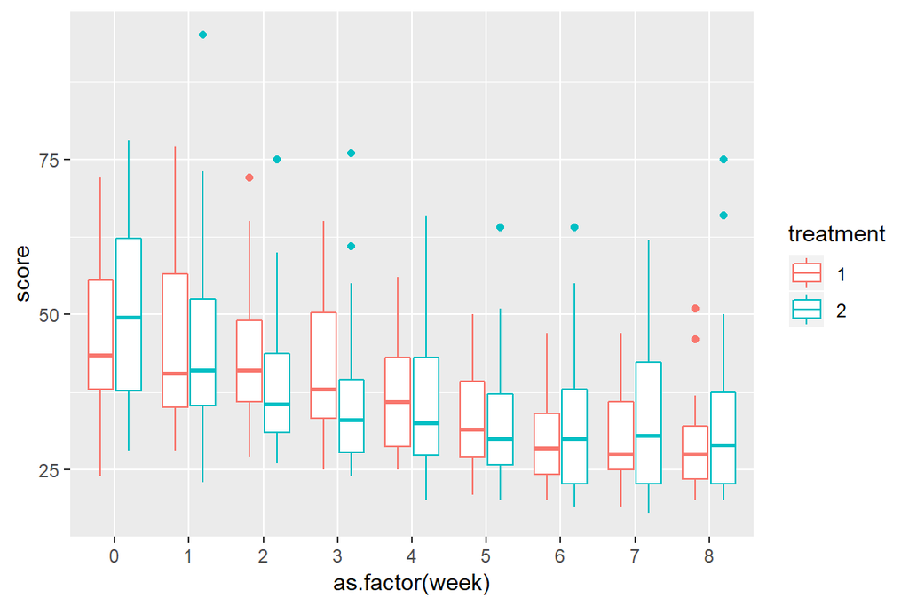

```r
ggplot(bprs, aes(x = as.factor(week), y = score, colour = treatment)) + geom_boxplot()
```

When looking at the line chart, we can see that with both treatments the scores have a huge drop between week one and five. With treatment 1 the drop continues till sixth week. After that there happens a small growth or almost nothing. As we noticed earlier, there were some outliers that may have some effect on the means. But still, the groups do not look much different. The similarity can be seen even more clearly in the boxplots. The outliers can be seen as the dots above the boxes.

#### Linear model

We can now start to trying different models. Let’s first start with linear model where we assume that all the observations are independent (even though we know they are not). As explonatory variables we’ll have `week` that is time as weeks, and `treatment` that we have used to group test subjects.

```r
bprs_reg <- lm(score ~ week + treatment, data = bprs)
summary(bprs_reg)
```

```
##
## Call:
## lm(formula = score ~ week + treatment, data = bprs)
##
## Residuals:
##     Min      1Q  Median      3Q     Max
## -22.454  -8.965  -3.196   7.002  50.244
##
## Coefficients:
##             Estimate Std. Error t value Pr(>|t|)
## (Intercept)  46.4539     1.3670  33.982   <2e-16 ***
## week         -2.2704     0.2524  -8.995   <2e-16 ***
## treatment2    0.5722     1.3034   0.439    0.661
## ---
## Signif. codes:  0 '***' 0.001 '**' 0.01 '*' 0.05 '.' 0.1 ' ' 1
##
## Residual standard error: 12.37 on 357 degrees of freedom
## Multiple R-squared:  0.1851, Adjusted R-squared:  0.1806
## F-statistic: 40.55 on 2 and 357 DF,  p-value: < 2.2e-16
```

I’ll explain the summary really briefly. If we first look at the Coefficients and the estimte, we’ll notice that our time variable has a negative value which means that the increase in the `week` variable would mean decrease in scores. The p-values indicate that the relastionship between `week` and `score` is significant, but between `treatment` and `score` is not. It is a bit dumb to make models like this since we have quite good knowledge of the relationships of the variables. Well, at least we know that there is no complete independency between scores. Let’s move to another model.

#### Random intercept model

This model is a little more evolved from the previous one because it allows men differ from each others in intercept (that’s where the name of the model comes from). Here is the model summary after setting the same explonatory variables as earlier (`week` and `treatment`):

```r
library(lme4)

bprs_ref <- lmer(score ~ week + treatment + (1 | id), data = bprs, REML = FALSE)
summary(bprs_ref)
```

```
## Linear mixed model fit by maximum likelihood  ['lmerMod']
## Formula: score ~ week + treatment + (1 | id)
##    Data: bprs
##
##      AIC      BIC   logLik deviance df.resid
##   2582.9   2602.3  -1286.5   2572.9      355
##
## Scaled residuals:
##      Min       1Q   Median       3Q      Max
## -2.27506 -0.59909 -0.06104  0.44226  3.15835
##
## Random effects:
##  Groups   Name        Variance Std.Dev.
##  id       (Intercept) 97.39    9.869
##  Residual             54.23    7.364
## Number of obs: 360, groups:  id, 40
##
## Fixed effects:
##             Estimate Std. Error t value
## (Intercept)  46.4539     2.3521  19.750
## week         -2.2704     0.1503 -15.104
## treatment2    0.5722     3.2159   0.178
##
## Correlation of Fixed Effects:
##            (Intr) week
## week       -0.256
## treatment2 -0.684  0.000
```

Now we can see from the Random effects from the summary that the variance between men is quite much, almost 100, which means that there are much differences between our test subjects when it comes to their BPRS overall. This was also seen from the plots. We can also see that the estimated values did not change much from the previous model, but the standard errors did. The error with time decreased because we now did assume the within subject dependency. However, the error of the treatment increased but it is explained by the data and the sample sizes between these models. The main difference compared to the ``week```variable is that treatment is associated with a phenomena between test subjcts, not within.

#### Random intercept and Slope model

Next we are going to fit a random intercept and a slope model to the data. This model assumes the dependency between subjects **and** also the effect of time, which is pretty important - as we may know:

```r
bprs_ref1 <- lmer(score ~ week + treatment + (week | id), data = bprs, REML = FALSE)

summary(bprs_ref1)
```

```
## Linear mixed model fit by maximum likelihood  ['lmerMod']
## Formula: score ~ week + treatment + (week | id)
##    Data: bprs
##
##      AIC      BIC   logLik deviance df.resid
##   2523.2   2550.4  -1254.6   2509.2      353
##
## Scaled residuals:
##     Min      1Q  Median      3Q     Max
## -2.4655 -0.5150 -0.0920  0.4347  3.7353
##
## Random effects:
##  Groups   Name        Variance Std.Dev. Corr
##  id       (Intercept) 167.827  12.955
##           week          2.331   1.527   -0.67
##  Residual              36.747   6.062
## Number of obs: 360, groups:  id, 40
##
## Fixed effects:
##             Estimate Std. Error t value
## (Intercept)  45.9830     2.6470  17.372
## week         -2.2704     0.2713  -8.370
## treatment2    1.5139     3.1392   0.482
##
## Correlation of Fixed Effects:
##            (Intr) week
## week       -0.545
## treatment2 -0.593  0.000
```

The statistics look pretty similar compared to the previous model but there has happened an improvement. If we compare this model and the previous one wit the ANOVA, we can see the change:

```r
anova(bprs_ref1, bprs_ref)
```

```
## Data: bprs
## Models:
## bprs_ref: score ~ week + treatment + (1 | id)
## bprs_ref1: score ~ week + treatment + (week | id)
##           Df    AIC    BIC  logLik deviance  Chisq Chi Df Pr(>Chisq)
## bprs_ref   5 2582.9 2602.3 -1286.5   2572.9
## bprs_ref1  7 2523.2 2550.4 -1254.6   2509.2 63.663      2  1.499e-14 ***
## ---
## Signif. codes:  0 '***' 0.001 '**' 0.01 '*' 0.05 '.' 0.1 ' ' 1
```

If we take a quick look at the p-value, it is really small which shows that the models do differ. Now that we have a model that contains necessary dependencies, we can actually examines the dependency between time and treatment!

#### Interaction

This will now be our final model that also notices the group and time interaction. Without other unnecessary explainings, let’s fit it:

```r
bprs_ref2 <- lmer(score ~ week * treatment + (week | id), data = bprs, REML = FALSE)

summary(bprs_ref2)
```

```
## Linear mixed model fit by maximum likelihood  ['lmerMod']
## Formula: score ~ week * treatment + (week | id)
##    Data: bprs
##
##      AIC      BIC   logLik deviance df.resid
##   2523.5   2554.5  -1253.7   2507.5      352
##
## Scaled residuals:
##     Min      1Q  Median      3Q     Max
## -2.4747 -0.5256 -0.0866  0.4435  3.7884
##
## Random effects:
##  Groups   Name        Variance Std.Dev. Corr
##  id       (Intercept) 164.207  12.814
##           week          2.203   1.484   -0.66
##  Residual              36.747   6.062
## Number of obs: 360, groups:  id, 40
##
## Fixed effects:
##                 Estimate Std. Error t value
## (Intercept)      47.8856     2.9840  16.047
## week             -2.6283     0.3752  -7.006
## treatment2       -2.2911     4.2201  -0.543
## week:treatment2   0.7158     0.5306   1.349
##
## Correlation of Fixed Effects:
##             (Intr) week   trtmn2
## week        -0.668
## treatment2  -0.707  0.473
## wek:trtmnt2  0.473 -0.707 -0.668
```

And here is the test when compared to previous model:

```r
anova(bprs_ref2, bprs_ref1)
```

```
## Data: bprs
## Models:
## bprs_ref1: score ~ week + treatment + (week | id)
## bprs_ref2: score ~ week * treatment + (week | id)
##           Df    AIC    BIC  logLik deviance Chisq Chi Df Pr(>Chisq)
## bprs_ref1  7 2523.2 2550.4 -1254.6   2509.2
## bprs_ref2  8 2523.5 2554.6 -1253.7   2507.5  1.78      1     0.1821
```

Oh, funny. It looks like there actually is no significant difference. It would indicate that when adding groups in the model they do not bring any significant value to it. So this might tell that there are no really difference between groups. We were assuming this when making the plots but this explains a little bit more. It would mean that the treatments do not differ when looking at the BPRS scores.

Here are the same plots than in the beginning but with fitted values:

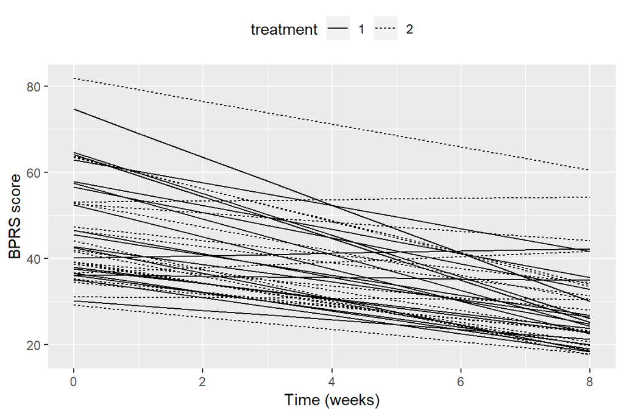

```r
Fitted <- fitted(bprs_ref2)

bprs <- bprs %>%
  mutate(Fitted)

ggplot(bprs, aes(x = week, y = Fitted, group = id)) +
  geom_line(aes(linetype = treatment)) +
  scale_x_continuous(name = "Time (weeks)", breaks = seq(0, 8, 2)) +
  scale_y_continuous(name = "BPRS score") +
  theme(legend.position = "top")
```

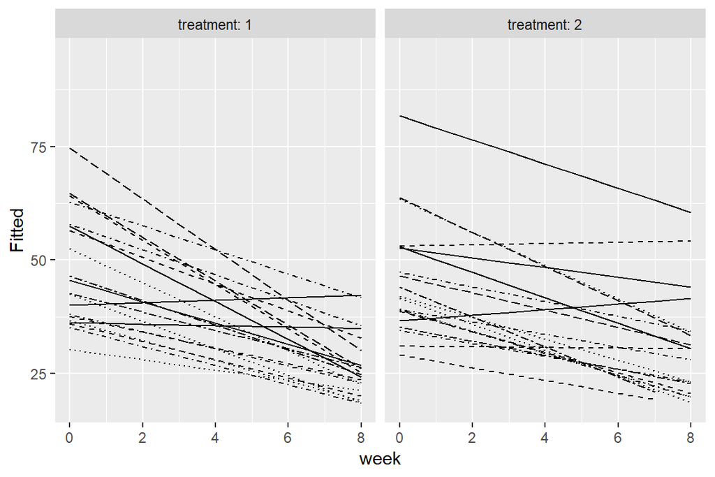

```r
ggplot(bprs, aes(x = week, y = Fitted, linetype = subject)) +
  geom_line() +
  scale_linetype_manual(values = rep(1:10, times = 4)) +
  facet_grid(. ~ treatment, labeller = label_both) +
  theme(legend.position = "none") +
  scale_y_continuous(limits = c(min(bprs$score), max(bprs$score)))
```

We can see from the plots that is made from the interaction model that it does make some kind of profiles, but they are pretty straight-forward compared to the real observed values. I would say it works a bit better with the treatment 1 than 2.